# ΜΙΣΤΑ002: Fisher’s exact test

## Fisher’s exact test

Fisher's exact test is a statistical test used to determine if there are non-random associations between two categorical variables. When the expected numbers are very small (expected frequencies less than 1 or more than 20% of the expected frequencies less than 5) the chi-square test is not a good approximation and the Fisher's exact test should be used instead.

For hand calculations, the test is only feasible in the case of a 2 × 2 contingency table. However, the principle of the test can be extended to the general case of an r × c table, and some statistical packages provide a calculation (sometimes using a Monte Carlo method to obtain an approximation) for the more general case.

**Fisher's exact test is most easily described in the context of a particular example using the notation of the 2x2 contingency table.**

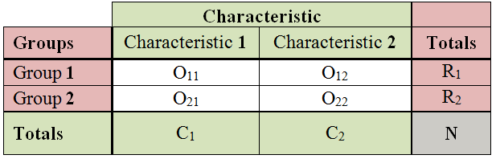

where  
O<sub>11</sub>, O<sub>12</sub>,O<sub>21</sub>,O<sub>22</sub>,: the number of observed frequencies in the cells  
R<sub>1,</sub>R<sub>1</sub>: the row marginal totals for the first and second row respectively  
C<sub>1</sub>, C<sub>2</sub>: the column marginal totals for the first and second column respectively  
N: the total sample size

Worked Example

[figure not shown]

The contingency table below shows the results from a study to compare two treatment regimens for controlling bleeding in hemophiliacs undergoing surgery. Only one (7.7%) of the 13 hemophiliacs given treatment regimen A suffered bleeding complications, compared to three (25%) of the 12 given regimen B. These numbers are too small for the chi-squared test to be valid; the overall total, 25, is relatively small, and the smallest expected value, (12x4)/25=1.92 (complications with regimen B ), is less than 5. The exact test is therefore indicated.

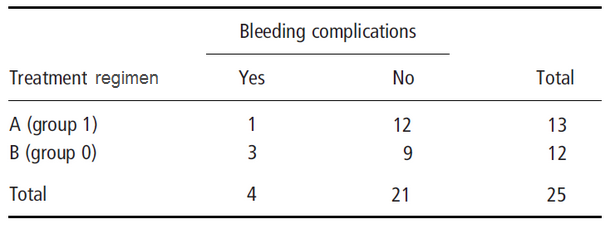

**Step 1. Define the null and alternative hypotheses under study**

**H<sub>0</sub>**: There is no association between the treatment regimens and the bleeding complications.

**H<sub>1</sub>**: There is a association between the treatment regimens and the bleeding complications.

**Step 2. Calculate the exact two tailed probability of the test specific to H<sub>0</sub>**

The exact test is based on calculating the exact probabilities of the observed table and of more ‘extreme’ tables with the same row and column totals, using the following formula:

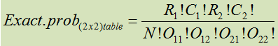

The exclamation mark denotes the factorial of the number and means that all the integers from the number down to 1 are multiplied together (0! is defined to equal 1). For example, 4!=4x3x2x1=24.

The exact probability of the observed table is therefore:

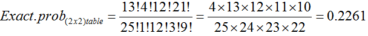

In order to test the null hypothesis that there is no difference between the treatment regimens, we need to calculate not only the probability of the observed table but also the probability that a more extreme table could occur by chance. Altogether there are five possible tables that have the same row and column totals as the data. These are shown in the below table together with their probabilities, which total 1. The observed case is the table (b) with a probability of 0.2261.

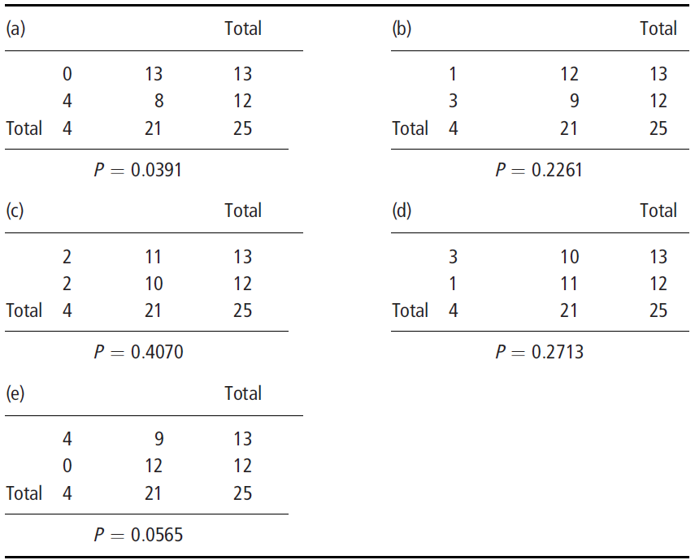

More extreme is defined as less probable; more extreme tables are therefore (a) and (e) with probabilities 0.0391 and 0.0565 respectively. The total probability needed for the two-tailed p-value is therefore 0.2261+0.0391+0.0565=0.3217.

**Step 3. Compare the exact p-value of the test to a=0.05 and interpret the result**

Exact p-value=0.3217>0.05, so there is no evidence against the null hypothesis of no association between the treatment regimens and the bleeding complications.

Last modified: Monday, 11 March 2019, 8:43 AM